Regresar a la página principal

# Tarea 2

John Jairo Leal

# Análisis de la Capacidad de Captación de CO2 en Plantas

## Cargue de las librerías y de la base de datos

```r
#Cargando Librerías
library(readr)
library(ggplot2)

#Leyendo la base de datos

CO2 <- read_delim("CO2.csv",
    delim = "\t", escape_double = FALSE,
    trim_ws = TRUE)
# Vista previa de las primeras filas de los datos
head(CO2)
```

```
## # A tibble: 6 × 5
##   Plant Type   Treatment   conc uptake
##   <chr> <chr>  <chr>      <dbl>  <dbl>
## 1 Qn1   Quebec nonchilled    95   16
## 2 Qn1   Quebec nonchilled   175   30.4
## 3 Qn1   Quebec nonchilled   250   34.8
## 4 Qn1   Quebec nonchilled   350   37.2
## 5 Qn1   Quebec nonchilled   500   35.3
## 6 Qn1   Quebec nonchilled   675   39.2
```

## Análisis exploratorio de los datos

A continuación hacemos un análisis inicial de los datos

```r
# Resumen estadístico de los datos
summary(CO2)
```

```
##     Plant               Type            Treatment              conc
##  Length:84          Length:84          Length:84          Min.   :  95
##  Class :character   Class :character   Class :character   1st Qu.: 175
##  Mode  :character   Mode  :character   Mode  :character   Median : 350
##                                                           Mean   : 435
##                                                           3rd Qu.: 675
##                                                           Max.   :1000
##      uptake
##  Min.   : 7.70
##  1st Qu.:17.90
##  Median :28.30
##  Mean   :27.21
##  3rd Qu.:37.12
##  Max.   :45.50
```

```r
# Calcular estadísticas descriptivas
mean(CO2$uptake)  # Media de la columna uptake
```

```
## [1] 27.2131
```

```r
sd(CO2$uptake)    # Desviación estándar de la columna uptake
```

```
## [1] 10.81441
```

## Visualzación: Diagrama de dispersión

Visualizamos los datos en un diagrama

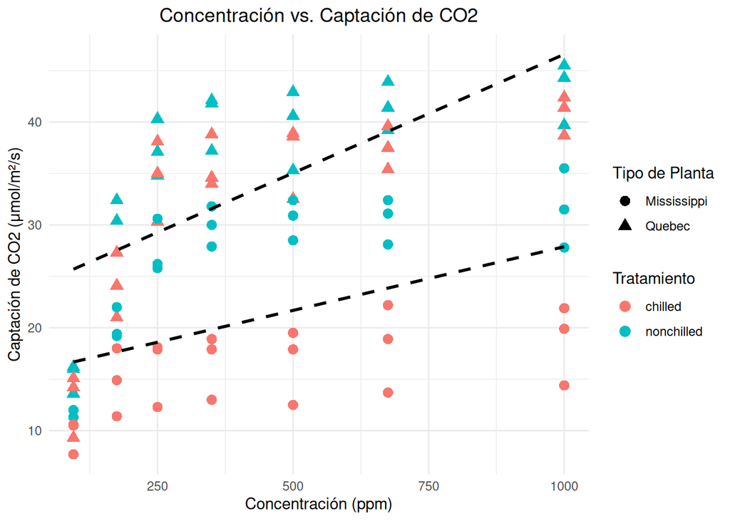

```r
# Gráfico de dispersión

ggplot(data = CO2, aes(x = conc, y = uptake, color = Treatment, shape = Type)) +
  geom_point(size = 3) +
  geom_smooth(method = "lm", se = FALSE, linetype = "dashed", color = "black") +
  labs(title = "Concentración vs. Captación de CO2",
       x = "Concentración (ppm)",
       y = "Captación de CO2 (μmol/m²/s)",
       color = "Tratamiento",
       shape = "Tipo de Planta") +
  theme_minimal() +
  theme(plot.title = element_text(hjust = 0.5))
```

Otro gráfico, por ubicación y tratamiento

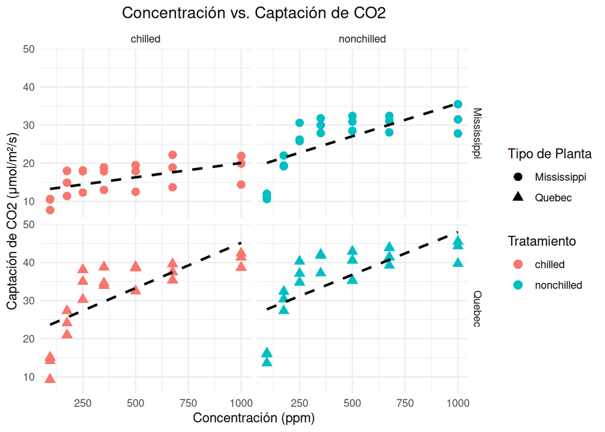

```r
# Gráfico por ubicación y tratamiento

ggplot(data = CO2, aes(x = conc, y = uptake, color = Treatment, shape = Type)) +
  geom_point(size = 3) +
  geom_smooth(method = "lm", se = FALSE, linetype = "dashed", color = "black") +
  labs(title = "Concentración vs. Captación de CO2",
       x = "Concentración (ppm)",
       y = "Captación de CO2 (μmol/m²/s)",
       color = "Tratamiento",
       shape = "Tipo de Planta") +
  theme_minimal() +
  theme(plot.title = element_text(hjust = 0.5)) +
  facet_grid(Type ~ Treatment)
```

El análisis de la capacidad de captación de CO2 en plantas de la familia de las gramíneas revela diferencias significativas en función de la ubicación (Quebec y Mississippi) y el tratamiento aplicado (chilled y nonchilled). Utilizando gráficos de dispersión, se observa que, en general, las plantas sometidas a temperaturas ambiente (nonchilled) muestran una mayor captación de CO2 en comparación con las plantas sometidas a refrigeración (chilled) en ambas ubicaciones. Además, se destaca que las plantas en Quebec tienen una mayor variabilidad en la captación de CO2 con el aumento de la concentración, especialmente en condiciones no refrigeradas. Los gráficos también indican que las plantas de Mississippi tienen una capacidad de captación de CO2 relativamente menor y menos variable en comparación con las de Quebec, sugiriendo que las condiciones climáticas y de tratamiento influyen notablemente en la eficiencia de la fotosíntesis y la absorción de CO2 en estas plantas.

# Análisis descriptivo de los datos

```r
library(dplyr)
# Cálculo de estadísticas descriptivas
descriptive_stats <- CO2 %>%
  group_by(Type, Treatment) %>%
  summarise(
    mean_uptake = mean(uptake),
    median_uptake = median(uptake),
    sd_uptake = sd(uptake),
    n = n()
  )
print(descriptive_stats)
```

```
## # A tibble: 4 × 6
## # Groups:   Type [2]
##   Type        Treatment  mean_uptake median_uptake sd_uptake     n
##   <chr>       <chr>            <dbl>         <dbl>     <dbl> <int>
## 1 Mississippi chilled           15.8          17.9      4.06    21
## 2 Mississippi nonchilled        26.0          28.1      7.40    21
## 3 Quebec      chilled           31.8          35        9.64    21
## 4 Quebec      nonchilled        35.3          39.2      9.60    21
```

Los resultados del análisis descriptivo revelan que las plantas de Quebec tienen una mayor capacidad de captación de CO2 en comparación con las plantas de Mississippi, independientemente del tratamiento aplicado. Específicamente, las plantas no refrigeradas en Quebec muestran una media de captación de CO2 de 35.3 μmol/m²/s, mientras que las plantas refrigeradas tienen una media de 31.8 μmol/m²/s. En Mississippi, las plantas no refrigeradas tienen una media de 26.0 μmol/m²/s, en contraste con las plantas refrigeradas que presentan una media de 15.8 μmol/m²/s. Las medianas de captación de CO2 confirman estas observaciones, indicando que las plantas no refrigeradas son más eficientes en la absorción de CO2 en ambas ubicaciones. Además, la variabilidad en la captación de CO2 es mayor en Quebec, reflejada en desviaciones estándar más altas, lo que puede sugerir una mayor heterogeneidad en la respuesta de las plantas a las condiciones ambientales específicas de esta región.

En términos de tratamiento, las plantas no refrigeradas (nonchilled) superan consistentemente a las plantas refrigeradas (chilled) en ambas ubicaciones. La diferencia en la media de captación de CO2 entre plantas no refrigeradas y refrigeradas es significativa, especialmente en Mississippi, donde las plantas no refrigeradas tienen una captación de CO2 promedio considerablemente mayor. Esta diferencia sugiere que la refrigeración reduce la eficiencia de la captación de CO2, posiblemente debido a una disminución en la tasa de fotosíntesis bajo condiciones de frío extremo. La mayor variabilidad observada en la captación de CO2 en Quebec podría ser el resultado de factores ambientales específicos o de diferencias en la respuesta individual de las plantas. En resumen, tanto la ubicación como el tratamiento influyen significativamente en la capacidad de captación de CO2, con las plantas de Quebec y las plantas no refrigeradas mostrando una mayor eficiencia en la absorción de CO2.

## Análisis de varianza ANOVA

```r
# ANOVA

anova_result <- aov(uptake ~ Type * Treatment * conc, data = CO2)
summary(anova_result)
```

```
##                     Df Sum Sq Mean Sq F value   Pr(>F)
## Type                 1   3366    3366 100.416 1.52e-15 ***
## Treatment            1    988     988  29.482 6.51e-07 ***
## conc                 1   2285    2285  68.177 3.55e-12 ***
## Type:Treatment       1    226     226   6.735   0.0113 *
## Type:conc            1    208     208   6.206   0.0149 *
## Treatment:conc       1     32      32   0.951   0.3326
## Type:Treatment:conc  1     56      56   1.657   0.2019
## Residuals           76   2547      34
## ---
## Signif. codes:  0 '***' 0.001 '**' 0.01 '*' 0.05 '.' 0.1 ' ' 1
```

El análisis de varianza (ANOVA) revela que tanto el tipo de planta, el tratamiento (chilled vs. nonchilled), y la concentración de CO2 tienen efectos significativos en la captación de CO2. Específicamente, las plantas de Quebec tienen una mayor captación de CO2 que las plantas de Mississippi, y las plantas no refrigeradas (nonchilled) captan significativamente más CO2 que las plantas refrigeradas (chilled) (F(1, 76) = 29.482, p < 0.001). Además, la concentración de CO2 tiene un efecto significativo (F(1, 76) = 68.177, p < 0.001), indicando que la captación de CO2 aumenta a medida que aumenta la concentración de CO2.

Las interacciones significativas entre el tipo de planta y el tratamiento (F(1, 76) = 6.735, p < 0.05), y entre el tipo de planta y la concentración de CO2 (F(1, 76) = 6.206, p < 0.05), sugieren que las plantas de Quebec y Mississippi responden de manera diferente a estos factores. Esto implica que el efecto del tratamiento (chilled vs. nonchilled) y la concentración de CO2 en la captación de CO2 varía según el tipo de planta. Sin embargo, la interacción entre tratamiento y concentración de CO2 no es significativa, lo que indica que el efecto de la concentración de CO2 en la captación de CO2 no varía significativamente entre plantas refrigeradas y no refrigeradas. La interacción triple entre tipo de planta, tratamiento y concentración de CO2 tampoco es significativa. En resumen, estos hallazgos subrayan la importancia de considerar múltiples factores y sus interacciones al evaluar la eficiencia de captación de CO2 en diferentes tipos de plantas y tratamientos.

## Análisis de correlación

```r
# Cálculo de la correlación
correlation_result <- cor(CO2$conc, CO2$uptake)
print(correlation_result)
```

```
## [1] 0.4851774
```

El análisis de correlación entre la concentración de CO2 y la captación de CO2 revela una correlación positiva moderada (coeficiente de correlación = 0.4851774), indicando que a medida que aumenta la concentración de CO2, también tiende a aumentar la captación de CO2. Este resultado respalda la conclusión del análisis de varianza (ANOVA), que identificó la concentración de CO2 como un factor significativo en la captación de CO2. Sin embargo, la correlación moderada sugiere que otros factores, como el tipo de planta y el tratamiento (chilled vs. nonchilled), también influyen en la capacidad de las plantas para captar CO2, como lo evidencian las interacciones significativas encontradas en el ANOVA. En conjunto, estos hallazgos subrayan la necesidad de considerar múltiples factores y sus interacciones para comprender completamente la dinámica de la captación de CO2 en las plantas.

## Boxplot

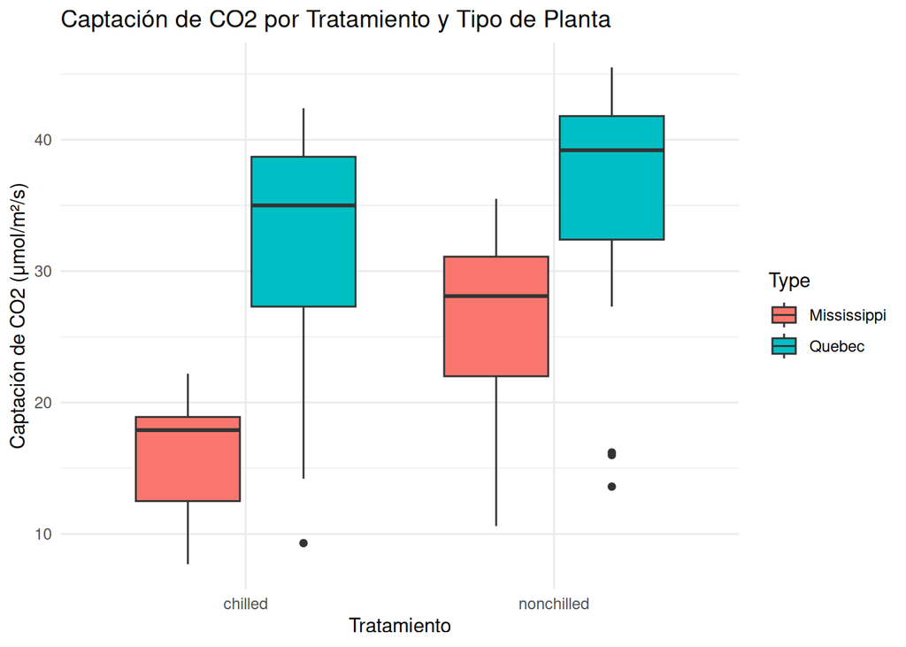

```r
# Boxplot de captación de CO2 por tratamiento y tipo
ggplot(CO2, aes(x = Treatment, y = uptake, fill = Type)) +
  geom_boxplot() +
  labs(title = "Captación de CO2 por Tratamiento y Tipo de Planta",
       x = "Tratamiento",
       y = "Captación de CO2 (μmol/m²/s)") +
  theme_minimal()
```

En el boxplot, la posición más elevada de las plantas de Quebec en comparación con las plantas de Mississippi indica una captación de CO2 significativamente mayor en Quebec en promedio. Esto sugiere que las condiciones ambientales y climáticas en Quebec pueden ser más propicias para la fotosíntesis y la captación de CO2 que en Mississippi. La diferencia en la posición de las cajas entre las dos ubicaciones geográficas refleja una variabilidad sistemática en la captación de CO2, lo que sugiere una influencia significativa del entorno en la eficiencia de las plantas para captar CO2. Esto destaca la importancia de considerar las condiciones locales al evaluar la capacidad de las plantas para mitigar el CO2 atmosférico y subraya la necesidad de estudios adicionales para comprender mejor los factores que contribuyen a estas diferencias geográficas en la captación de CO2.

## Gráfico de violín

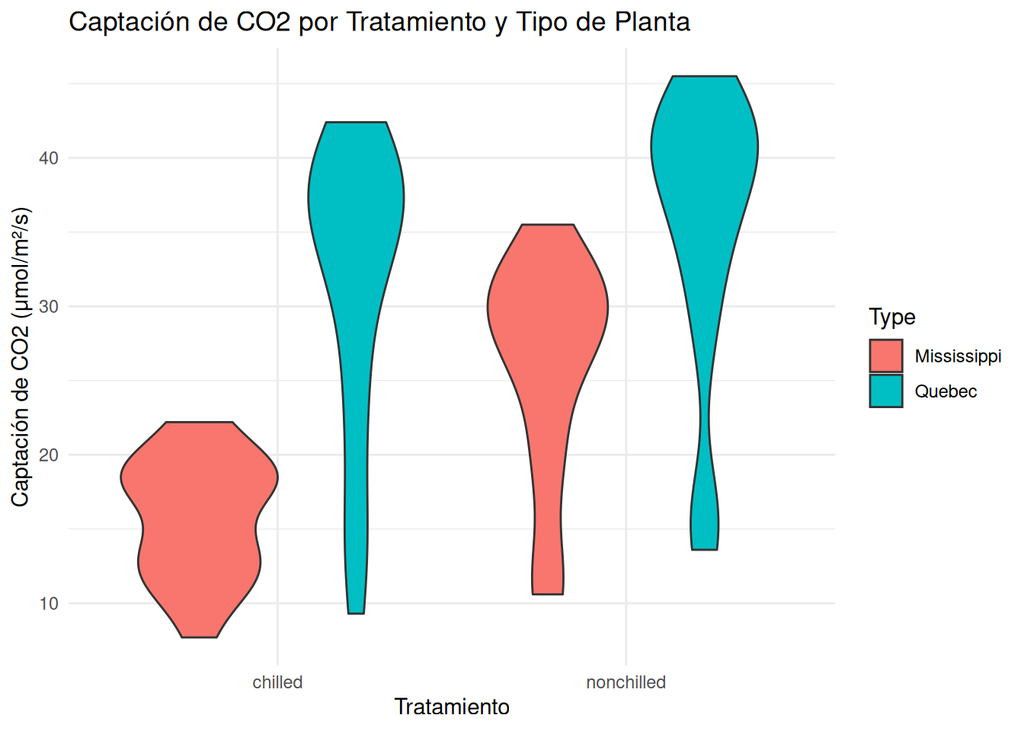

```r
# Gráfico de violín de captación de CO2 por tratamiento y tipo
ggplot(CO2, aes(x = Treatment, y = uptake, fill = Type)) +
  geom_violin() +
  labs(title = "Captación de CO2 por Tratamiento y Tipo de Planta",
       x = "Tratamiento",
       y = "Captación de CO2 (μmol/m²/s)") +
  theme_minimal()
```

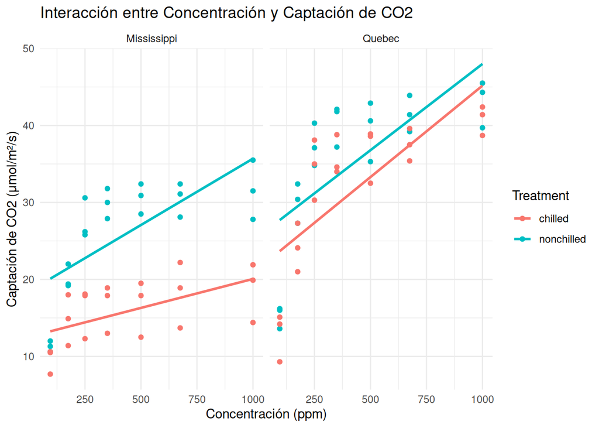

```r
# Gráfico de interacción para explorar la interacción entre concentración y captación de CO2
ggplot(CO2, aes(x = conc, y = uptake, color = Treatment)) +
  geom_point() +
  geom_smooth(method = "lm", se = FALSE) +
  facet_wrap(~ Type) +
  labs(title = "Interacción entre Concentración y Captación de CO2",
       x = "Concentración (ppm)",
       y = "Captación de CO2 (μmol/m²/s)") +
  theme_minimal()
```

La gráfica de interacción revela diferencias significativas en la respuesta de las plantas al tratamiento (refrigerado vs. no refrigerado) entre las ubicaciones geográficas de Mississippi y Quebec. En Mississippi, la línea correspondiente al tratamiento “nonchilled” se sitúa claramente por encima de la línea “chilled”, indicando una mayor captación de CO2 en las plantas no refrigeradas. Esta diferencia es notable y sugiere un efecto marcado del tratamiento en la captación de CO2 en este entorno. Por otro lado, en Quebec, aunque la línea “nonchilled” también se encuentra por encima de la línea “chilled”, la separación entre ellas es menos pronunciada, lo que sugiere un efecto menos diferenciado del tratamiento en la captación de CO2 en comparación con Mississippi. Esto podría indicar que las condiciones ambientales en Quebec podrían amortiguar los efectos del tratamiento, resaltando la importancia de considerar tanto el tratamiento como el entorno local al evaluar la eficacia de las estrategias de mitigación del CO2 en las plantas.

## Conclusiones

Los diversos análisis realizados proporcionan una visión comprehensiva de la capacidad de las plantas para captar CO2, destacando la influencia de múltiples factores. Desde el ANOVA, se identificó que tanto el tipo de planta, el tratamiento y la concentración de CO2 tienen efectos significativos en la captación de CO2. Esto sugiere que las diferencias geográficas y ambientales pueden influir en la capacidad de las plantas para realizar la fotosíntesis y captar CO2. Además, la correlación moderada entre la concentración de CO2 y la captación de CO2 indica que, si bien la concentración de CO2 influye en la captación, otros factores también desempeñan un papel importante. Los gráficos de boxplot y violín muestran claramente las diferencias en la captación de CO2 entre las plantas de Quebec y Mississippi, subrayando la importancia de considerar el entorno local al evaluar esta capacidad. Por último, la gráfica de interacción resalta que el efecto del tratamiento puede variar dependiendo de la ubicación geográfica, lo que destaca la necesidad de estudios más detallados para comprender completamente la dinámica de la captación de CO2 en diferentes contextos.

En resumen, estos análisis proporcionan una comprensión más profunda de la compleja interacción entre los factores ambientales, el tratamiento y la captación de CO2 en las plantas. Los resultados sugieren que, si bien la concentración de CO2 es un factor importante, las diferencias geográficas y ambientales también juegan un papel significativo en la capacidad de las plantas para captar CO2. Lo anterior, tiene implicaciones importantes para la comprensión de la respuesta de las plantas al cambio climático y la formulación de estrategias efectivas para mitigar las emisiones de CO2 a través de la conservación y gestión de los ecosistemas vegetales.